# Road_Safety

### Context:

UK Road Casualty data for the year 2022. Has the detailed data that police recorded on all the accidents occurred across UK.

### Objective:

1. Pedestrians
2. Drivers
3. Cyclists

### Key Questions:

1. When are the pedestrians involved in the accident?
2. What wrong the car drivers do in key road signals, which causes accidents?
3. What cyclists need to follow while using the road? How they can avoid being hit by other road users?
4. What is the general age of car drivers who involved in the accidents?
5. Which road points are more prone to accidents?

### Data Description:

## Vehicle Dataset

- **accident_index**: unique value for each accident. The accident_index combines the accident_year and accident_ref_no to form a unique ID. It can be used to join to Vehicle and Casualty
- **accident_year**: the year the accident occurred
- **accident_reference**:
- **vehicle_reference**:
- **vehicle_type**:

  ```
  1   Pedal cycle
  2   Motorcycle 50cc and under
  3   Motorcycle 125cc and under
  4   Motorcycle over 125cc and up to 500cc
  5   Motorcycle over 500cc
  8   Taxi/Private hire car
  9   Car
  10  Minibus (8 - 16 passenger seats)
  11  Bus or coach (17 or more pass seats)
  16  Ridden horse
  17  Agricultural vehicle
  18  Tram
  19  Van / Goods 3.5 tonnes mgw or under
  20  Goods over 3.5t. and under 7.5t
  21  Goods 7.5 tonnes mgw and over
  22  Mobility scooter
  23  Electric motorcycle
  90  Other vehicle
  97  Motorcycle - unknown cc
  98  Goods vehicle - unknown weight
  99  Unknown vehicle type (self rep only)
  -1  Data missing or out of range
  ```

- **towing_and_articulation**:

  ```
  0   No tow/articulation
  1   Articulated vehicle
  2   Double or multiple trailer
  3   Caravan
  4   Single trailer
  5   Other tow
  9   unknown (self reported)
  -1  Data missing or out of range
  ```

- **vehicle_manoeuvre**:

  ```
  1   Reversing
  2   Parked
  3   Waiting to go - held up
  4   Slowing or stopping
  5   Moving off
  6   U-turn
  7   Turning left
  8   Waiting to turn left
  9   Turning right
  10  Waiting to turn right
  11  Changing lane to left
  12  Changing lane to right
  13  Overtaking moving vehicle - offside
  14  Overtaking static vehicle - offside
  15  Overtaking - nearside
  16  Going ahead left-hand bend
  17  Going ahead right-hand bend
  18  Going ahead other
  99  unknown (self reported)
  -1  Data missing or out of range
  ```

- **vehicle_direction_from**:

  ```
  0   Parked
  1   North
  2   North East
  3   East
  4   South East
  5   South East
  6   South West
  7   West
  8   North West
  9   unknown (self reported)
  -1  Data missing or out of range
  ```

- **vehicle_direction_to**:

  ```
  0   Parked
  1   North
  2   North East
  3   East
  4   South East
  5   South East
  6   South West
  7   West
  8   North West
  9   unknown (self reported)
  -1  Data missing or out of range
  ```

- **vehicle_location_restricted_lane**:

  ```
  0   On main c'way - not in restricted lane
  1   Tram/Light rail track
  2   Bus lane
  3   Busway (including guided busway)
  4   Cycle lane (on main carriageway)
  5   Cycleway or shared use footway (not part of  main carriageway)
  6   On lay-by or hard shoulder
  7   Entering lay-by or hard shoulder
  8   Leaving lay-by or hard shoulder
  9   Footway (pavement)
  10  Not on carriageway
  99  unknown (self reported)
  -1  Data missing or out of range
  ```

- **junction_location**:

  ```
  0   Not at or within 20 metres of junction
  1   Approaching junction or waiting/parked at junction approach
  2   Cleared junction or waiting/parked at junction exit
  3   Leaving roundabout
  4   Entering roundabout
  5   Leaving main road
  6   Entering main road
  7   Entering from slip road
  8   Mid Junction - on roundabout or on main road
  9   unknown (self reported)
  -1  Data missing or out of range
  ```

- **skidding_and_overturning**:

  ```
  0   None
  1   Skidded
  2   Skidded and overturned
  3   Jackknifed
  4   Jackknifed and overturned
  5   Overturned
  9   unknown (self reported)
  -1  Data missing or out of range
  ```

- **hit_object_in_carriageway**:

  ```
  0   None
  1   Previous accident
  2   Road works
  4   Parked vehicle
  5   Bridge (roof)
  6   Bridge (side)
  7   Bollard or refuge
  8   Open door of vehicle
  9   Central island of roundabout
  10  Kerb
  11  Other object
  12  Any animal (except ridden horse)
  99  unknown (self reported)
  -1  Data missing or out of range
  ```

- **vehicle_leaving_carriageway**:

  ```
  0   Did not leave carriageway
  1   Nearside
  2   Nearside and rebounded
  3   Straight ahead at junction
  4   Offside on to central reservation
  5   Offside on to centrl res + rebounded
  6   Offside - crossed central reservation
  7   Offside
  8   Offside and rebounded
  9   unknown (self reported)
  -1  Data missing or out of range
  ```

- **hit_object_off_carriageway**:

  ```
  0   None
  1   Road sign or traffic signal
  2   Lamp post
  3   Telegraph or electricity pole
  4   Tree
  5   Bus stop or bus shelter
  6   Central crash barrier
  7   Near/Offside crash barrier
  8   Submerged in water
  9   Entered ditch
  10  Other permanent object
  11  Wall or fence
  99  unknown (self reported)
  -1  Data missing or out of range
  ```

- **first_point_of_impact**:

  ```
  0   Did not impact
  1   Front
  2   Back
  3   Offside
  4   Nearside
  9   unknown (self reported)
  -1  Data missing or out of range
  ```

- **vehicle_left_hand_drive**:

  ```
  1   No
  2   Yes
  9   Unknown
  -1  Data missing or out of range
  ```

- **journey_purpose_of_driver**:

  ```
  1   Journey as part of work
  2   Commuting to/from work
  3   Taking pupil to/from school
  4   Pupil riding to/from school
  5   Other
  6   Not known
  15  Other/Not known
  -1  Data missing or out of range
  ```

- **sex_of_driver**:

  ```
  1   Male
  2   Female
  3   Not known
  -1  Data missing or out of range
  ```

- **age_of_driver**:
- **age_band_of_driver**:

  ```
  1   0 - 5
  2   6 - 10
  3   11 - 15
  4   16 - 20
  5   21 - 25
  6   26 - 35
  7   36 - 45
  8   46 - 55
  9   56 - 65
  10  66 - 75
  11  Over 75
  -1  Data missing or out of range
  ```

- **engine_capacity_cc**:
- **propulsion_code**:

  ```
  1   Petrol
  2   Heavy oil
  3   Electric
  4   Steam
  5   Gas
  6   Petrol/Gas (LPG)
  7   Gas/Bi-fuel
  8   Hybrid electric
  9   Gas Diesel
  10  New fuel technology
  11  Fuel cells
  12  Electric diesel
  -1  Undefined
  ```

- **age_of_vehicle**:
- **generic_make_model**:
- **driver_imd_decile**:

  ```
  1   Most deprived 10%
  2   More deprived 10-20%
  3   More deprived 20-30%
  4   More deprived 30-40%
  5   More deprived 40-50%
  6   Less deprived 40-50%
  7   Less deprived 30-40%
  8   Less deprived 20-30%
  9   Less deprived 10-20%
  10  Least deprived 10%
  -1  Data missing or out of range
  ```

- **driver_home_area_type**:

  ```
  1   Urban area
  2   Small town
  3   Rural
  -1  Data missing or out of range
  ```

- **lsoa_of_driver**:

## Casualty DataSet

- **accident_index**: unique value for each accident. The accident_index combines the accident_year and accident_ref_no to form a unique ID. It can be used to join to Vehicle and Casualty
- **accident_year**: the year the accident occurred
- **accident_reference**:
- **vehicle_reference**:
- **casualty_reference**:
- **casualty_class**:

  ```
  1   Driver or rider
  2   Passenger
  3   Pedestrian
  ```

- **sex_of_casualty**:

  ```
  1   Male
  2   Female
  9   unknown (self reported)
  ```

- **age_of_casualty**:
- **age_band_of_casualty**:

  ```
  1   0 - 5
  2   6 - 10
  3   11 - 15
  4   16 - 20
  5   21 - 25
  6   26 - 35
  7   36 - 45
  8   46 - 55
  9   56 - 65
  10  66 - 75
  11  Over 75
  ```

- **casualty_severity**:

  ```
  1   Fatal
  2   Serious
  3   Slight
  ```

- **pedestrian_location**:

  ```
  0   Not a Pedestrian
  1   Crossing on pedestrian crossing facility
  2   Crossing in zig-zag approach lines
  3   Crossing in zig-zag exit lines
  4   Crossing elsewhere within 50m. of pedestrian crossing
  5   In carriageway, crossing elsewhere
  6   On footway or verge
  7   On refuge, central island or central reservation
  8   In centre of carriageway - not on refuge, island or central reservation
  9   In carriageway, not crossing
  10  Unknown or other
  ```

- **pedestrian_movement**:

  ```
  0   Not a Pedestrian
  1   Crossing from driver's nearside
  2   Crossing from nearside - masked by parked or stationary vehicle
  3   Crossing from driver's offside
  4   Crossing from offside - masked by  parked or stationary vehicle
  5   In carriageway, stationary - not crossing  (standing or playing)
  6   In carriageway, stationary - not crossing  (standing or playing) - masked by parked or stationary vehicle
  7   Walking along in carriageway, facing traffic
  8   Walking along in carriageway, back to traffic
  9   Unknown or other
  ```

- **car_passenger**:

  ```
  0   Not car passenger
  1   Front seat passenger
  2   Rear seat passenger
  9   unknown (self reported)
  ```

- **bus_or_coach_passenger**:

  ```
  0   Not a bus or coach passenger
  1   Boarding
  2   Alighting
  3   Standing passenger
  4   Seated passenger
  9   unknown (self reported)
  ```

- **pedestrian_road_maintenance_worker**:

  ```
  0   No / Not applicable
  1   Yes
  2   Not Known
  3   Probable
  ```

- **casualty_type**:

  ```
  0   Pedestrian
  1   Cyclist
  2   Motorcycle 50cc and under rider or passenger
  3   Motorcycle 125cc and under rider or passenger
  4   Motorcycle over 125cc and up to 500cc rider or  passenger
  5   Motorcycle over 500cc rider or passenger
  8   Taxi/Private hire car occupant
  9   Car occupant
  10  Minibus (8 - 16 passenger seats) occupant
  11  Bus or coach occupant (17 or more pass seats)
  16  Horse rider
  17  Agricultural vehicle occupant
  18  Tram occupant
  19  Van / Goods vehicle (3.5 tonnes mgw or under) occupant
  20  Goods vehicle (over 3.5t. and under 7.5t.) occupant
  21  Goods vehicle (7.5 tonnes mgw and over) occupant
  22  Mobility scooter rider
  23  Electric motorcycle rider or passenger
  90  Other vehicle occupant
  97  Motorcycle - unknown cc rider or passenger
  98  Goods vehicle (unknown weight) occupant
  99  Unknown vehicle type (self rep only)
  ```

- **casualty_home_area_type**:

  ```
  1   Urban area
  2   Small town
  3   Rural
  ```

- **casualty_imd_decile**:

  ```
  1   Most deprived 10%
  2   More deprived 10-20%
  3   More deprived 20-30%
  4   More deprived 30-40%
  5   More deprived 40-50%
  6   Less deprived 40-50%
  7   Less deprived 30-40%
  8   Less deprived 20-30%
  9   Less deprived 10-20%
  10  Least deprived 10%
  ```

- **lsoa_of_casualty**: local_authority_ons_district of the casualty

## Collision Dataset

- **accident_index**:
- **accident_year**:
- **accident_reference**:
- **location_easting_osgr**:
- **location_northing_osgr**:
- **longitude**:
- **latitude**:
- **police_force**:
- **accident_severity**:

  ```
  1   Fatal
  2   Serious
  3   Slight
  ```

- **number_of_vehicles**:
- **number_of_casualties**:
- **date**:
- **day_of_week**:

  ```
  1   Sunday
  2   Monday
  3   Tuesday
  4   Wednesday
  5   Thursday
  6   Friday
  7   Saturday
  ```

- **time**:
- **local_authority_district**:
- **local_authority_ons_district**:
- **local_authority_highway**:
- **first_road_class**:

  ```
  1   Motorway
  2   A(M)
  3   A
  4   B
  5   C
  6   Unclassified
  -1  Data missing or out of range
  ```

- **first_road_number**:

  ```
  1 to 9999   Number range
  -1  Unknown
  0   first_road_class is C or Unclassified. These roads do not have official numbers so recorded as zero
  ```

- **road_type**:

  ```
  1   Roundabout
  2   One way street
  3   Dual carriageway
  6   Single carriageway
  7   Slip road
  9   Unknown
  12  One way street/Slip road
  -1  Data missing or out of range
  ```

- **speed_limit**:

  ```
  20,30,40,50,60,70 are the only valid speed limits on public highways
  -1  Data missing or out of range
  99  unknown (self reported)
  ```

- **junction_detail**:

  ```
  0   Not at junction or within 20 metres
  1   Roundabout
  2   Mini-roundabout
  3   T or staggered junction
  5   Slip road
  6   Crossroads
  7   More than 4 arms (not roundabout)
  8   Private drive or entrance
  9   Other junction
  99  unknown (self reported)
  -1  Data missing or out of range
  ```

- **junction_control**:

  ```
  0   Not at junction or within 20 metres
  1   Authorised person
  2   Auto traffic signal
  3   Stop sign
  4   Give way or uncontrolled
  -1  Data missing or out of range
  9   unknown (self reported)
  ```

- **second_road_class**:

  ```
  0   Not at junction or within 20 metres
  1   Motorway
  2   A(M)
  3   A
  4   B
  5   C
  6   Unclassified
  9   Unknown (self rep only)
  -1  Data missing or out of range
  ```

- **second_road_number**:

  ```
  1 to 9999   Number range
  -1  Unknown
  0   first_road_class is C or Unclassified. These roads do not have official numbers so recorded as zero
  ```

- **pedestrian_crossing_human_control**:

  ```
  0   None within 50 metres
  1   Control by school crossing patrol
  2   Control by other authorised person
  -1  Data missing or out of range
  9   unknown (self reported)
  ```

- **pedestrian_crossing_physical_facilities**:

  ```
  0   No physical crossing facilities within 50 metres
  1   Zebra
  4   Pelican, puffin, toucan or similar non-junction pedestrian light crossing
  5   Pedestrian phase at traffic signal junction
  7   Footbridge or subway
  8   Central refuge
  -1  Data missing or out of range
  9   unknown (self reported)
  ```

- **light_conditions**:

  ```
  1   Daylight
  4   Darkness - lights lit
  5   Darkness - lights unlit
  6   Darkness - no lighting
  7   Darkness - lighting unknown
  -1  Data missing or out of range
  ```

- **weather_conditions**:

  ```
  1   Fine no high winds
  2   Raining no high winds
  3   Snowing no high winds
  4   Fine + high winds
  5   Raining + high winds
  6   Snowing + high winds
  7   Fog or mist
  8   Other
  9   Unknown
  -1  Data missing or out of range
  ```

- **road_surface_conditions**:

  ```
  1   Dry
  2   Wet or damp
  3   Snow
  4   Frost or ice
  5   Flood over 3cm. deep
  6   Oil or diesel
  7   Mud
  -1  Data missing or out of range
  9   unknown (self reported)
  ```

- **special_conditions_at_site**:

  ```
  0   None
  1   Auto traffic signal - out
  2   Auto signal part defective
  3   Road sign or marking defective or obscured
  4   Roadworks
  5   Road surface defective
  6   Oil or diesel
  7   Mud
  -1  Data missing or out of range
  9   unknown (self reported)
  ```

- **carriageway_hazards**:

  ```
  0   None
  1   Vehicle load on road
  2   Other object on road
  3   Previous accident
  4   Dog on road
  5   Other animal on road
  6   Pedestrian in carriageway - not injured
  7   Any animal in carriageway (except ridden horse)
  -1  Data missing or out of range
  9   unknown (self reported)
  ```

- **urban_or_rural_area**:

  ```
  1   Urban
  2   Rural
  3   Unallocated
  -1  Data missing or out of range
  ```

- **did_police_officer_attend_scene_of_accident**:

  ```
  1   Yes
  2   No
  3   No - accident was reported using a self completion  form (self rep only)
  -1  Data missing or out of range
  ```

- **trunk_road_flag**:

  ```
  1   Trunk (Roads managed by Highways England)
  2   Non-trunk
  -1  Data missing or out of range
  ```

- **lsoa_of_accident_location**:

## **Analysis**

### **Importing the necessary libraries**

```python
# Libraries to help with reading and manipulating data
import numpy as np
import pandas as pd

# Libraries to help with data visualization
import matplotlib.pyplot as plt
import seaborn as sns
%matplotlib inline
```

### **Loading the Dataset**

#### Mount the Drive

```python
from google.colab import drive
drive.mount('/content/drive')
```

#### Open the csv

```python
df_casualty = pd.read_csv('/content/drive/My Drive/Colab/EDA_Road_Safety_CaseStudy/dft-road-casualty-statistics-casualty-2022.csv')
df_collision = pd.read_csv('/content/drive/My Drive/Colab/EDA_Road_Safety_CaseStudy/dft-road-casualty-statistics-collision-2022.csv')
df_vehicle = pd.read_csv('/content/drive/My Drive/Colab/EDA_Road_Safety_CaseStudy/dft-road-casualty-statistics-vehicle-2022.csv')
df_metadata = pd.read_csv('/content/drive/My Drive/Colab/EDA_Road_Safety_CaseStudy/Master_Dict/meta_data_dictionary.csv')
```

```python
df_casualty.describe().T
# df_collision.describe().T
# df_vehicle.describe().T
df_casualty.head()
df_vehicle.head()
df_collision.head()
df_metadata.head()
```

|  | field_name | code | label |
| --- | --- | --- | --- |
| 0 | police_force | 1 | Metropolitan Police |
| 1 | police_force | 3 | Cumbria |
| 2 | police_force | 4 | Lancashire |
| 3 | police_force | 5 | Merseyside |
| 4 | police_force | 6 | Greater Manchester |

#### Observations

1. There are many fields that contain null values and are represented as -1
2. Almost all the fields are category fields except for age_of_casualty
3. As they are represent in numbers, they need to joined with appropriate master tables to get the value out of it.

```python
# merge all 3 datafames into one. Collision, Vehicle and Casualty
df_collision_vehicle = df_collision.merge(df_vehicle, left_on="accident_reference", right_on="accident_reference")
df_collision_vehicle_casualty = df_collision_vehicle.merge(df_casualty, left_on="accident_reference", right_on="accident_reference")
df_collision_vehicle_casualty[['accident_index','accident_index_x','accident_index_y']]
```

|  | accident_index | accident_index_x | accident_index_y |
| --- | --- | --- | --- |
| 0 | 2022010352073 | 2022010352073 | 2022010352073 |
| 1 | 2022010352073 | 2022010352073 | 2022010352073 |
| 2 | 2022010352573 | 2022010352573 | 2022010352573 |
| 3 | 2022010352573 | 2022010352573 | 2022010352573 |
| 4 | 2022010352575 | 2022010352575 | 2022010352575 |
| ... | ... | ... | ... |
| 168879 | 2022991162012 | 2022991162012 | 2022991162012 |
| 168880 | 2022991162012 | 2022991162012 | 2022991162012 |
| 168881 | 2022991162014 | 2022991162014 | 2022991162014 |
| 168882 | 2022991162022 | 2022991162022 | 2022991162022 |
| 168883 | 2022991162022 | 2022991162022 | 2022991162022 |

168884 rows × 3 columns

```python
# drop few columns which are not going to be used

columns_to_remove = ['accident_index_x','accident_index_y','accident_year', 'accident_year_x', 'accident_year_y','vehicle_reference_x','towing_and_articulation','vehicle_direction_from','vehicle_direction_to','skidding_and_overturning','hit_object_off_carriageway','first_point_of_impact','vehicle_left_hand_drive','engine_capacity_cc','propulsion_code','age_of_vehicle','generic_make_model','driver_imd_decile','driver_home_area_type','lsoa_of_driver','location_easting_osgr','location_northing_osgr','longitude','latitude','police_force','local_authority_district','local_authority_ons_district','local_authority_highway','first_road_number','first_road_number','special_conditions_at_site','urban_or_rural_area','did_police_officer_attend_scene_of_accident','trunk_road_flag','lsoa_of_accident_location','casualty_severity','car_passenger','bus_or_coach_passenger','pedestrian_road_maintenance_worker','casualty_home_area_type','casualty_imd_decile','lsoa_of_casualty']

df_with_necessary_columns = df_collision_vehicle_casualty.drop(columns=columns_to_remove)
```

```python
# convert datatypes of category variables
# list all the columns that needs to be converted to category datatype

columns_to_convert_to_category_datatypes = ['accident_index','vehicle_type','casualty_reference','vehicle_reference_y','vehicle_manoeuvre','second_road_class','second_road_number','vehicle_location_restricted_lane','junction_location','hit_object_in_carriageway','vehicle_leaving_carriageway','journey_purpose_of_driver','sex_of_driver','age_band_of_driver','accident_severity','day_of_week','first_road_class','road_type','speed_limit','junction_detail','junction_control','pedestrian_crossing_human_control','pedestrian_crossing_physical_facilities','light_conditions','weather_conditions','road_surface_conditions','carriageway_hazards','casualty_class','sex_of_casualty','age_band_of_casualty','pedestrian_location','pedestrian_movement','casualty_type']

df_with_necessary_columns[columns_to_convert_to_category_datatypes] = df_with_necessary_columns[columns_to_convert_to_category_datatypes].apply(lambda x: x.astype('category'))
df_main = df_with_necessary_columns.copy()
```

**Filters** Vehicle Type --> Car

Questions

1. When did the most collisions happened?
2. What time in the weekday the collisions happened?
3. What time in the weekend the collisions happened?
4. What are type of roads and the speed limit of the road the collisions happened?
5. In which roads Car drivers have to be careful?
6. If a pedestrian in involved in the accident then how?
7. If a cyclist is involved then how?
8. Which season the most accident happen?

```python
# vehicle_type
# df_main["vehicle_type"].drop_duplicates()
df_vehicles_in_most_accidents = df_main.groupby(['vehicle_type'])['accident_reference'].count().reset_index(name='accidents').sort_values(by=['accidents'], ascending=False)
df_vehicles_in_most_accidents[df_vehicles_in_most_accidents['accidents'] > 5000]
```

|  | vehicle_type | accidents |
| --- | --- | --- |
| 7 | 9 | 119682 |
| 1 | 1 | 11824 |
| 13 | 19 | 10626 |
| 3 | 3 | 7639 |

### Coding section

Analysis are done for Car, Cycle, Motor Cycle and Van vehicle types only. Because those the vehicle types that have high number of collisions.

```python
# split the data by the vehicle types, considering only 4 vehicle types as mentioned

# 9 - Car
# 1 - Pedal Cycle
# 19 - Van / Goods 3.5 tonnes mgw or under
# 3 - Motorcycle 125cc and under

df_car = df_main[df_main['vehicle_type'] == 9]
df_cycle = df_main[df_main['vehicle_type'] == 1]
df_van = df_main[df_main['vehicle_type'] == 19]
df_motor_cycle = df_main[df_main['vehicle_type'] == 3]
```

```python
def replace_values(df_main, df_replacement, column_name, column_name_desc):
  df_reference = df_metadata[df_metadata['field_name'] == column_name].loc[:,['code','label']]
  df_reference.columns = [column_name, column_name_desc]
  df_reference.set_index(column_name, inplace=True)
  dictionary = df_reference.to_dict(orient='dict')[column_name_desc]
  df_temp = df_main.copy()
  df_temp[column_name] = df_temp[column_name].astype('str')
  df_temp[column_name] = df_temp[column_name].replace(dictionary)
  return df_temp
```

```python
from matplotlib import pyplot as plt

def generate_count_plot(df_data, column_name, chart_title, xlabel, ylabel):
  # plot type
  sns.set(style="whitegrid")
  plt.figure(figsize=(8, 6))
  # generate the count plot for the variable
  sns.countplot(data=df_data, x=column_name, palette='viridis')
  # set the axis labels and title
  plt.title(chart_title)
  plt.xlabel(xlabel)
  plt.ylabel(ylabel)
  plt.xticks(rotation=90)
  # show the plot
  plt.show()

def generate_count_plot_horizontal(df_data, column_name, chart_title, xlabel, ylabel):
  # plot type
  sns.set(style="whitegrid")
  plt.figure(figsize=(8, 6))
  # generate the count plot for the variable
  sns.countplot(data=df_data, y=column_name, palette='viridis')
  # set the axis labels and title
  plt.title(chart_title)
  plt.xlabel(xlabel)
  plt.ylabel(ylabel)
  #plt.xticks(rotation=90)
  # show the plot
  plt.show()

def generate_count_plot_with_hue(df_data, column_name, hue_column, chart_title, xlabel, ylabel, hue_label):
  # plot type
  sns.set(style="whitegrid")
  plt.figure(figsize=(8, 6))
  # generate the count plot for the variable
  ax = sns.countplot(data=df_data, x=column_name, hue=hue_column, palette='Set2')

  # Add legend title
  legend = ax.legend(title=hue_label)
  legend.get_title().set_fontsize('12')  # Set the font size if neede

  # set the axis labels and title
  plt.title(chart_title)
  plt.xlabel(xlabel)
  plt.ylabel(ylabel)
  plt.xticks(rotation=90)
  # show the plot
  plt.show()

def generate_count_plot_with_hue_horizontal(df_data, column_name, hue_column, chart_title, xlabel, ylabel, hue_label):
  # plot type
  sns.set(style="whitegrid")
  plt.figure(figsize=(8, 6))
  # generate the count plot for the variable
  ax = sns.countplot(data=df_data, y=column_name, hue=hue_column, palette='Set2')

  # Add legend title
  legend = ax.legend(title=hue_label)
  legend.get_title().set_fontsize('12')  # Set the font size if neede

  # set the axis labels and title
  plt.title(chart_title)
  plt.xlabel(xlabel)
  plt.ylabel(ylabel)
  # show the plot
  plt.show()
```

```python
def generate_vehicle_specific_charts(df_main):
  df_copy = replace_values(df_main, df_metadata, 'road_type', 'road_type_desc')
  generate_count_plot(df_copy, 'road_type', 'Collisions by Road Type', 'Road Type','Collisions')

  df_copy = replace_values(df_main, df_metadata, 'first_road_class', 'first_road_class_desc')
  generate_count_plot(df_copy, 'first_road_class', 'Collisions by Road Class', 'Road Class','Collisions')

  df_copy = replace_values(df_main, df_metadata, 'junction_detail', 'junction_detail_desc')
  generate_count_plot(df_copy, 'junction_detail', 'Collisions by Junction Info', 'Junction Info','Collisions')

  df_copy = replace_values(df_main, df_metadata, 'speed_limit', 'speed_limit_desc')
  generate_count_plot(df_copy, 'speed_limit', 'Collisions by Speed limit of road', 'Speed Limit','Collisions')

  df_copy = df_main[df_main['pedestrian_location'] != 0]
  df_copy = replace_values(df_copy, df_metadata, 'pedestrian_location', 'pedestrian_location_desc')
  generate_count_plot(df_copy, 'pedestrian_location', 'Collisions by Pedestrian location', 'Pedestrian Location','Collisions')

  df_copy = df_main[df_main['pedestrian_movement'] != 0]
  df_copy = replace_values(df_copy, df_metadata, 'pedestrian_movement', 'pedestrian_movement_desc')
  generate_count_plot(df_copy, 'pedestrian_movement', 'Collisions by Pedestrian Movement', 'Pedestrian Movement','Collisions')
```

## Collisions involving Car

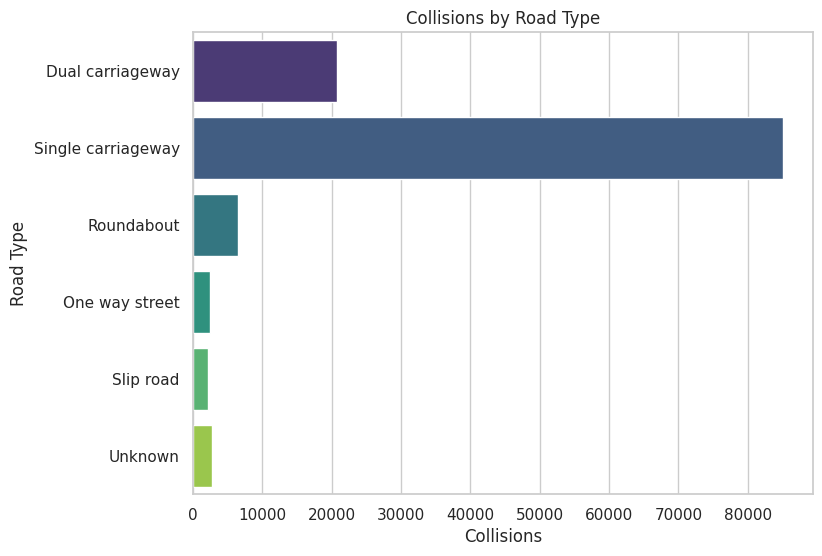

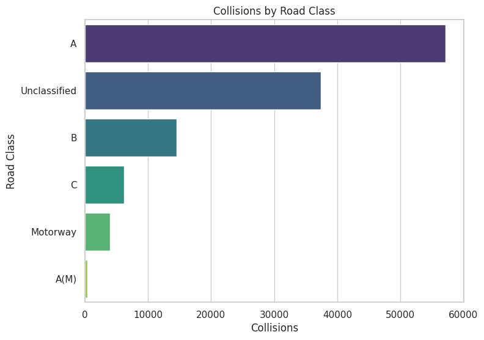

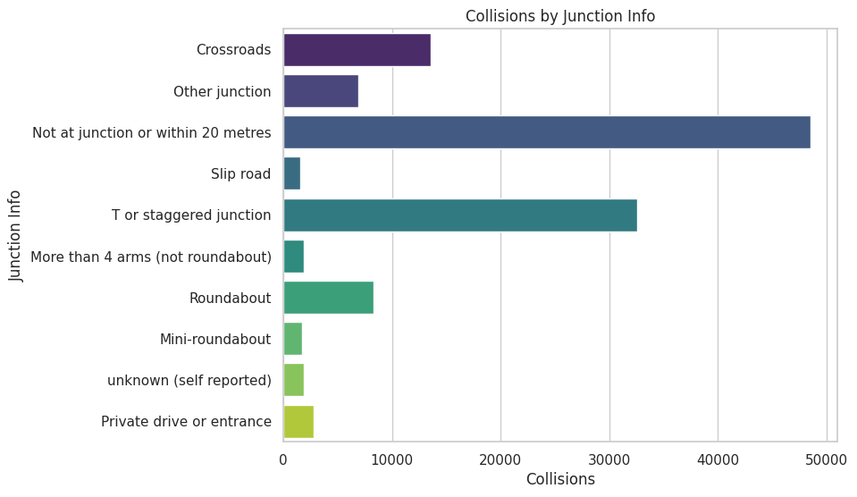

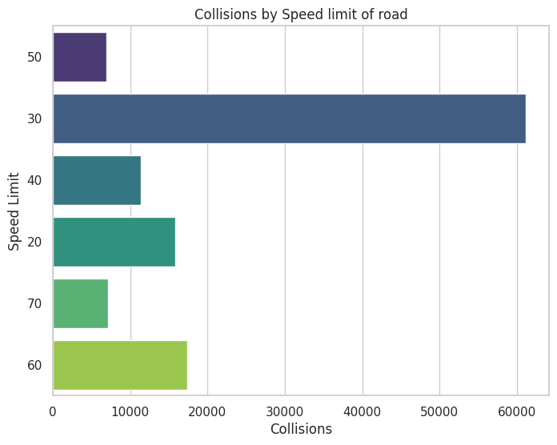

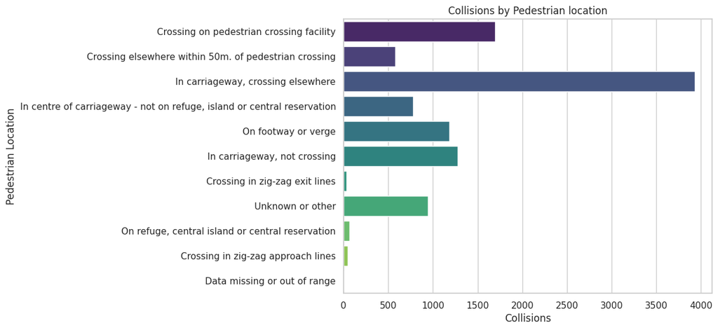

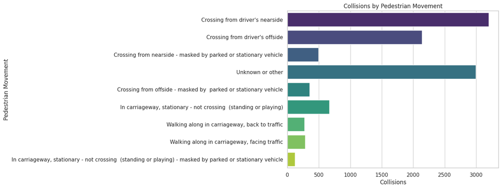

```python
df_copy = replace_values(df_car, df_metadata, 'road_type', 'road_type_desc')
generate_count_plot_horizontal(df_copy, 'road_type', 'Collisions by Road Type','Collisions', 'Road Type')

df_copy = replace_values(df_car, df_metadata, 'first_road_class', 'first_road_class_desc')
generate_count_plot_horizontal(df_copy, 'first_road_class', 'Collisions by Road Class','Collisions', 'Road Class')

df_copy = replace_values(df_car, df_metadata, 'junction_detail', 'junction_detail_desc')
generate_count_plot_horizontal(df_copy, 'junction_detail', 'Collisions by Junction Info','Collisions', 'Junction Info')

df_copy = replace_values(df_car, df_metadata, 'speed_limit', 'speed_limit_desc')
generate_count_plot_horizontal(df_copy, 'speed_limit', 'Collisions by Speed limit of road','Collisions', 'Speed Limit')

df_copy = df_car[df_car['pedestrian_location'] != 0]
df_copy = replace_values(df_copy, df_metadata, 'pedestrian_location', 'pedestrian_location_desc')
generate_count_plot_horizontal(df_copy, 'pedestrian_location', 'Collisions by Pedestrian location', 'Collisions', 'Pedestrian Location')

df_copy = df_car[df_car['pedestrian_movement'] != 0]
df_copy = replace_values(df_copy, df_metadata, 'pedestrian_movement', 'pedestrian_movement_desc')
generate_count_plot_horizontal(df_copy, 'pedestrian_movement', 'Collisions by Pedestrian Movement','Collisions', 'Pedestrian Movement')
```

Observations

1. Data shows the Single carriage way has the most number of collisions

## Collisions involving Pedal Cycle

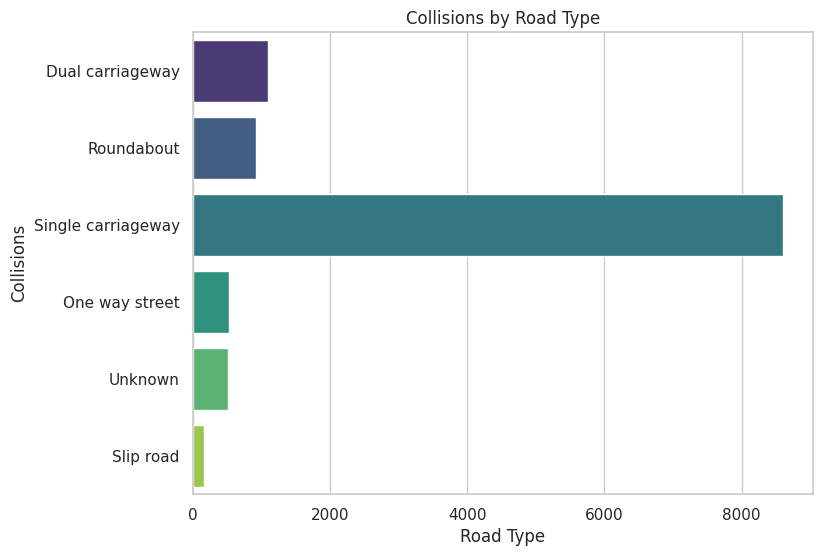

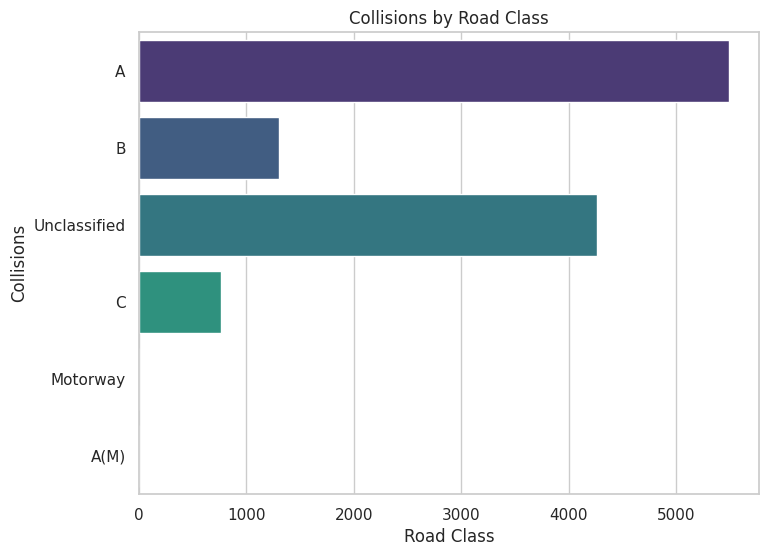

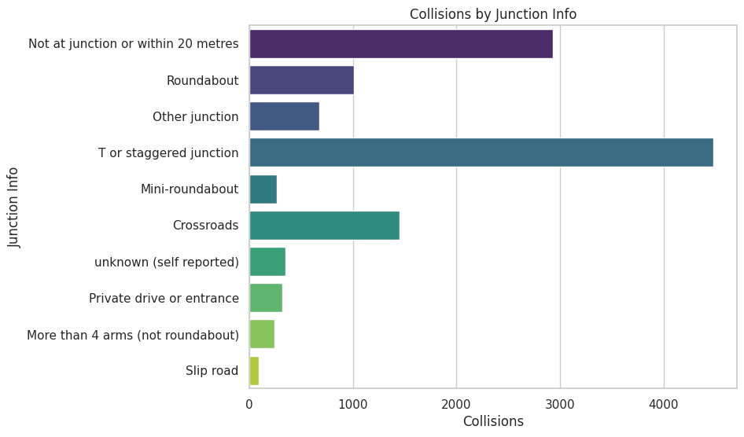

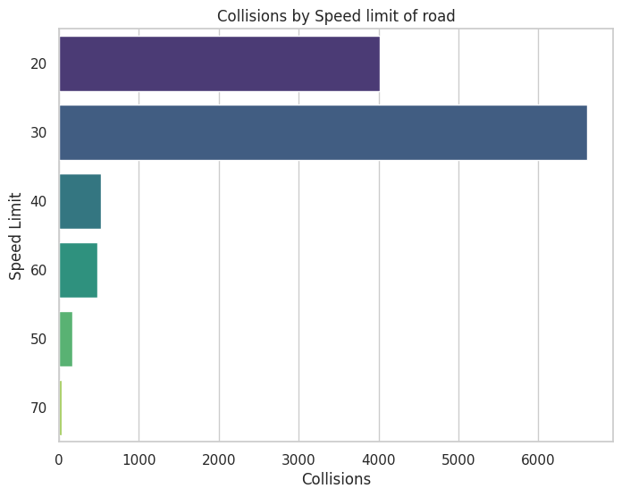

```python
df_copy = replace_values(df_cycle, df_metadata, 'road_type', 'road_type_desc')
generate_count_plot_horizontal(df_copy, 'road_type', 'Collisions by Road Type', 'Road Type','Collisions')

df_copy = replace_values(df_cycle, df_metadata, 'first_road_class', 'first_road_class_desc')
generate_count_plot_horizontal(df_copy, 'first_road_class', 'Collisions by Road Class', 'Road Class','Collisions')

df_copy = replace_values(df_cycle, df_metadata, 'junction_detail', 'junction_detail_desc')
generate_count_plot_horizontal(df_copy, 'junction_detail', 'Collisions by Junction Info', 'Collisions', 'Junction Info')

df_copy = replace_values(df_cycle, df_metadata, 'speed_limit', 'speed_limit_desc')
generate_count_plot_horizontal(df_copy, 'speed_limit', 'Collisions by Speed limit of road','Collisions', 'Speed Limit')
#generate_vehicle_specific_charts(df_cycle)
```

## Collisions involving Motor Cycle

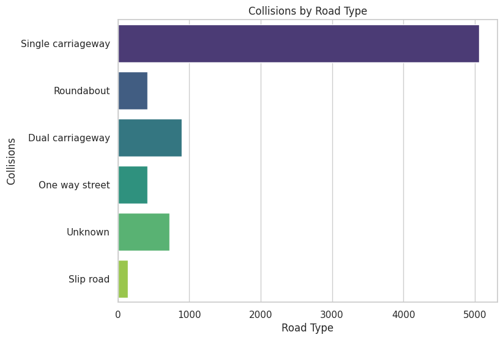

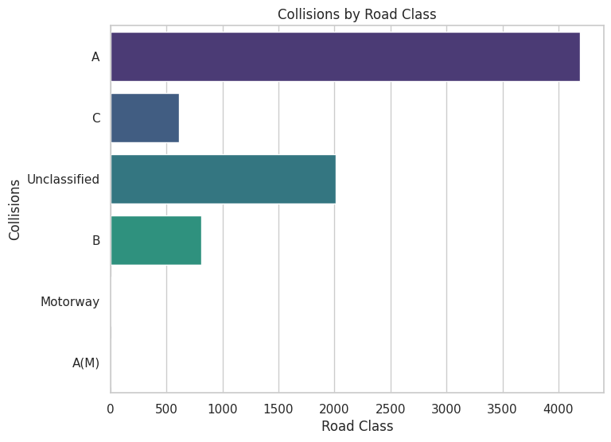

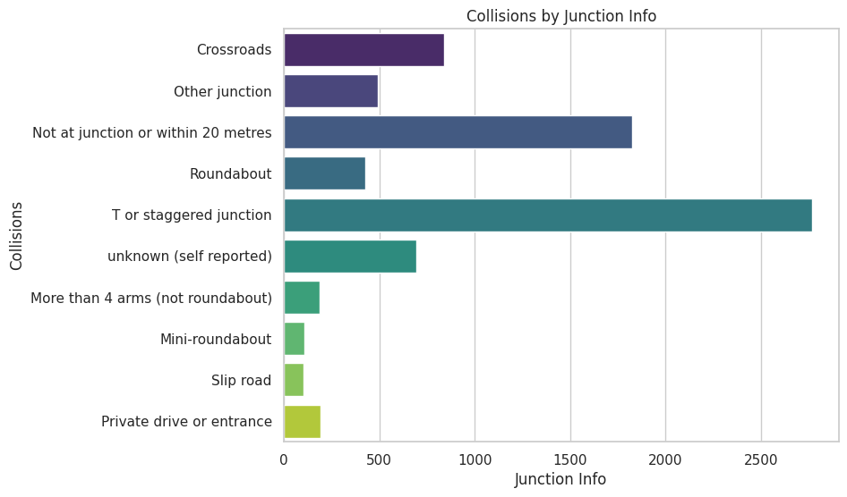

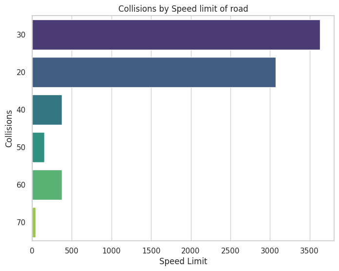

```python
df_copy = replace_values(df_motor_cycle, df_metadata, 'road_type', 'road_type_desc')
generate_count_plot_horizontal(df_copy, 'road_type', 'Collisions by Road Type', 'Road Type','Collisions')

df_copy = replace_values(df_motor_cycle, df_metadata, 'first_road_class', 'first_road_class_desc')
generate_count_plot_horizontal(df_copy, 'first_road_class', 'Collisions by Road Class', 'Road Class','Collisions')

df_copy = replace_values(df_motor_cycle, df_metadata, 'junction_detail', 'junction_detail_desc')
generate_count_plot_horizontal(df_copy, 'junction_detail', 'Collisions by Junction Info', 'Junction Info','Collisions')

df_copy = replace_values(df_motor_cycle, df_metadata, 'speed_limit', 'speed_limit_desc')
generate_count_plot_horizontal(df_copy, 'speed_limit', 'Collisions by Speed limit of road', 'Speed Limit','Collisions')
```

## Collisions involving Vans

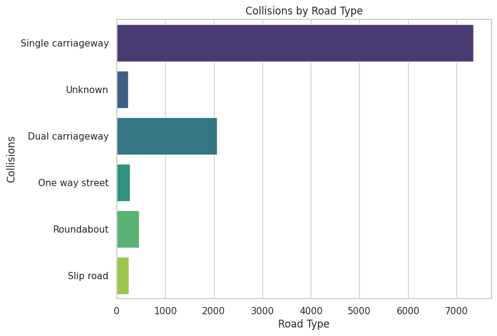

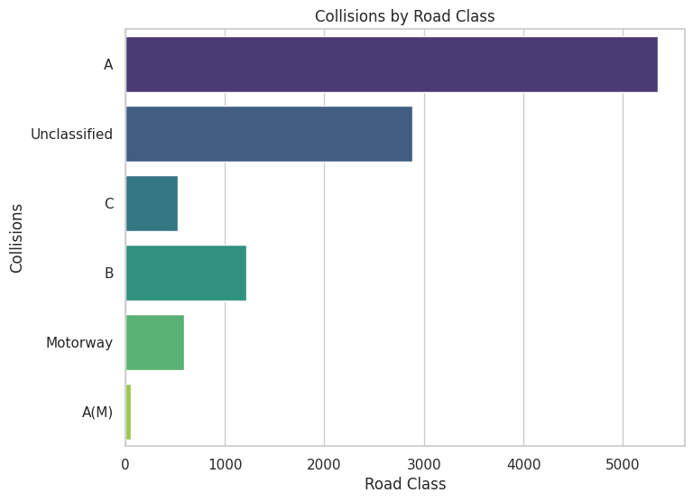

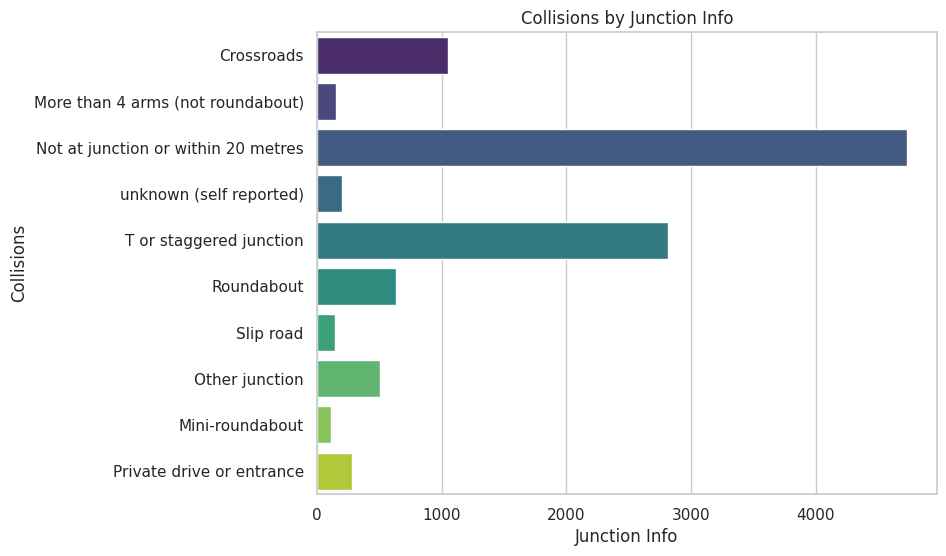

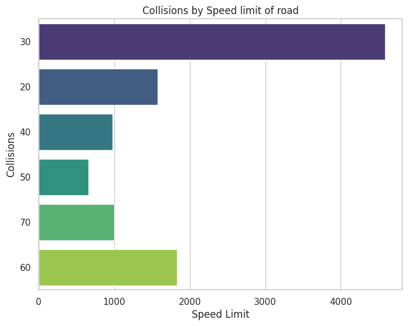

```python
df_copy = replace_values(df_van, df_metadata, 'road_type', 'road_type_desc')
generate_count_plot_horizontal(df_copy, 'road_type', 'Collisions by Road Type', 'Road Type','Collisions')

df_copy = replace_values(df_van, df_metadata, 'first_road_class', 'first_road_class_desc')
generate_count_plot_horizontal(df_copy, 'first_road_class', 'Collisions by Road Class', 'Road Class','Collisions')

df_copy = replace_values(df_van, df_metadata, 'junction_detail', 'junction_detail_desc')
generate_count_plot_horizontal(df_copy, 'junction_detail', 'Collisions by Junction Info', 'Junction Info','Collisions')

df_copy = replace_values(df_van, df_metadata, 'speed_limit', 'speed_limit_desc')
generate_count_plot_horizontal(df_copy, 'speed_limit', 'Collisions by Speed limit of road', 'Speed Limit','Collisions')
```

## Collisions by all vehicles by Road Type and Class

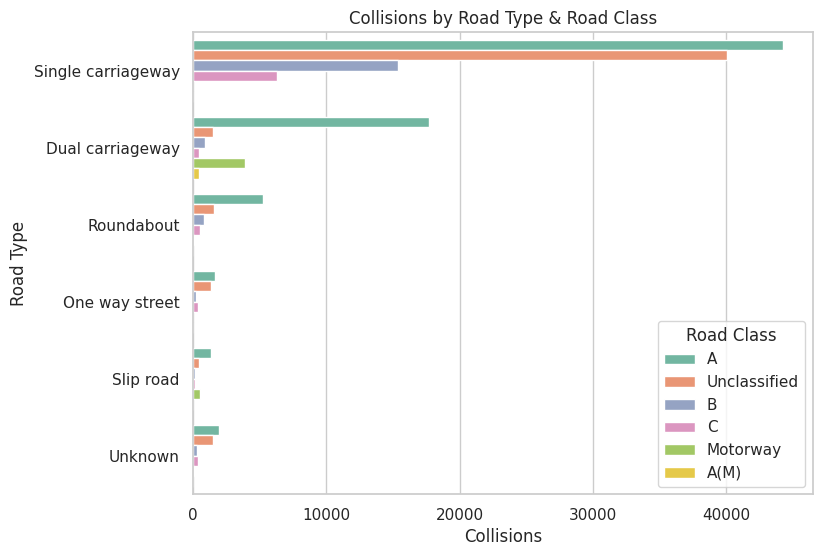

```python
df_vehicle_filter = df_main[df_main['vehicle_type'].isin([9,1,19,3])]
df_temp = replace_values(df_vehicle_filter, df_metadata, 'road_type', 'road_type_desc')
df_temp = replace_values(df_temp, df_metadata, 'first_road_class', 'first_road_class_desc')
#generate_count_plot_with_hue(df_temp, 'road_type','first_road_class', 'Collisions by Road Type & Road Class', 'Road Type','Collisions', 'Road Class')
generate_count_plot_with_hue_horizontal(df_temp, 'road_type','first_road_class', 'Collisions by Road Type & Road Class', 'Collisions','Road Type', 'Road Class')
```